# Comparação entre os modelos de seleção genômica RRblup e GBlup

Renato Gonçalves de Oliveira

23 de junho de 2021

Dentre os modelos disponíveis para a construção de modelos para a seleção genômica, os modelos RRblup e GBlup forma escolhidos para que suas saídas fossem comparadas neste trabalho. A equação de relação entre os dois modelos é descrita abaixo:

$$\hat{m} = (Z´Z)*Z´\hat{g}$$

Onde:

- $\hat{m}$: efeito estimado dos marcadores;
- Z: matriz dos estados dos marcadores para cada genótipo;
- $\hat{g}$: genomic estimated breeding values (GEBV´s).

O modelo RRblup fornece com saída os valores de $\hat{m}$. Esses valores correspondem aos efeitos estimados para os marcadores utilizados no modelo. O modelo GBlup apresenta como saída os valores de $\hat{g}$, que são os valores dos Blups estimados pelo modelo, ou GBlups. Esses valores correspondem aos valores genômicos preditos, ou GEBV´s. Para que se obtenham os valores os valores de GEBV´s à partir do modelo RRblup é preciso multiplicar os valores estimados dos efeitos dos marcadores, $\hat{m}$, pelo estado desses marcadores nos genótipos. O somatório desses efeitos deve ser acrescido do valor do instercepto estimado, $\hat{\beta}$. Dessa forma, a relação entre os valores da saída do modelo RRblup e GBlup pode ser descrita pela equação abaixo:

$$RRblup = (Z´Z)*Z´GBlup$$

# Pacotes utilizados na análise

```r
library(rrBLUP)
library(bWGR)
library(lattice)
```

# Arquivos de dados

Dois conjuntos de dados serão utilizados para a comparação dos modelos de seleção genômica. O arquivo de dados gentípicos é composto pelo resultado da genotipagem de 2025 indivíduos utilizando 453 marcadores. O arquivos de dados fenotípicos é composto por 5 caráteres avaliados em 1000 indivíduos.

```r
gen <- read.table("genotype.txt",header=TRUE)
phe <- read.table("phenotype.txt",header=TRUE)
```

## Arquivo de dados genotípicos

Corresponde aos dados dos estados dos marcadores dos indvíduos genotipados.

```r
gen[1:10, 1:10]
```

|  | m1 | m2 | m3 | m4 | m5 | m6 | m7 | m8 | m9 | m10 |
| --- | --- | --- | --- | --- | --- | --- | --- | --- | --- | --- |
| 301 | 1 | 0 | 0 | 0 | 0 | 0 | 0 | 0 | 2 | 2 |
| 302 | 0 | 0 | 0 | 0 | 0 | 0 | 0 | 0 | 1 | 2 |
| 303 | 0 | 0 | 0 | 0 | 0 | 0 | 0 | 0 | 1 | 1 |
| 304 | 0 | 0 | 0 | 0 | 1 | 0 | 0 | 0 | 1 | 2 |
| 305 | 0 | 0 | 0 | 0 | 1 | 0 | 0 | 0 | 0 | 2 |
| 306 | 0 | 0 | 0 | 0 | 1 | 0 | 0 | 0 | 1 | 1 |
| 307 | 0 | 0 | 0 | 0 | 1 | 0 | 0 | 0 | 1 | 2 |
| 308 | 0 | 0 | 0 | 0 | 2 | 0 | 0 | 0 | 0 | 1 |
| 309 | 0 | 0 | 0 | 0 | 0 | 0 | 0 | 0 | 1 | 1 |
| 310 | 0 | 0 | 0 | 0 | 0 | 0 | 1 | 1 | 2 | 1 |

```r
NA
```

## Arquivo de dados fenotípicos

Dos 5 caráteres avaliados do arquivos de dados genotípicos o que será utilizado será o p530.

```r
phe[1:10, ]
```

|  | ind | p0 | p132 | p265 | p397 | p530 |
| --- | --- | --- | --- | --- | --- | --- |
| 1 | 346 | 0.2999 | 1.3938 | 4.0470 | 8.9365 | 14.4663 |
| 2 | 347 | 0.4265 | 1.9578 | 6.6809 | 15.9458 | 27.3269 |
| 3 | 348 | 0.4991 | 2.0284 | 6.0664 | 13.7166 | 22.7103 |
| 4 | 349 | 0.1739 | 1.2515 | 4.4695 | 11.0793 | 18.7735 |
| 5 | 350 | 0.3712 | 1.8365 | 5.9575 | 14.4277 | 23.8408 |
| 6 | 351 | 0.2727 | 1.3336 | 3.9884 | 8.7238 | 14.1380 |
| 7 | 352 | 1.1542 | 3.7294 | 9.8721 | 20.2459 | 32.2920 |
| 8 | 353 | 0.3175 | 1.7614 | 5.6780 | 13.8240 | 22.7556 |
| 9 | 354 | 0.1726 | 1.2156 | 4.4640 | 11.2814 | 19.6790 |
| 10 | 355 | 0.6935 | 2.8703 | 8.4873 | 19.1791 | 30.8544 |

```r
NA
```

# Informações do arquivo de dados

O conjunto de dados utilizados para comparação dos dois modelos de seleção genômica possui as seguintes informações:

- n.° de machos: 5
- n.° de fêmeas: 20
- n.° de indivíduos fenotipados: 1000
- n.° de indivíduos genotipados: 2025
- tamanho efetivo da população (Ne): 16
- herdabilidade para o fenótipo $h^2a$: 0.47
- acurácia da seleção fenotípica: 0.73
- comprimento do genoma: 500 cM
- acurácia esperada para a seleção genômica: 0.67

# Modelo RRblup

## Matriz M

A matriz M, também conhecida como matriz Z, é a matriz que corresponde aos estados dos marcadores para cada um dos indivíduos genotipados. Para criar a matriz M foram colocados o nome dos genòtipos na linhas, usando os nomes do arquivos de dados fenotípicos, e o nome dos marcadores nas colunas.

```r
M <- gen[as.character(phe$ind),]
M[1:15,1:15]
```

|  | m1 | m2 | m3 | m4 | m5 | m6 | m7 | m8 | m9 | m10 | m11 | m12 | m13 | m14 | m15 |
| --- | --- | --- | --- | --- | --- | --- | --- | --- | --- | --- | --- | --- | --- | --- | --- |
| 346 | 1 | 0 | 0 | 0 | 1 | 0 | 0 | 0 | 1 | 1 | 0 | 1 | 1 | 2 | 0 |
| 347 | 1 | 0 | 0 | 0 | 1 | 0 | 0 | 0 | 1 | 1 | 0 | 1 | 1 | 2 | 0 |
| 348 | 1 | 0 | 0 | 0 | 0 | 0 | 0 | 0 | 1 | 2 | 0 | 2 | 2 | 2 | 0 |
| 349 | 0 | 0 | 0 | 0 | 1 | 0 | 0 | 0 | 1 | 1 | 0 | 1 | 1 | 2 | 0 |
| 350 | 1 | 0 | 0 | 0 | 1 | 0 | 0 | 0 | 1 | 1 | 0 | 1 | 1 | 2 | 0 |
| 351 | 0 | 0 | 0 | 0 | 1 | 0 | 0 | 0 | 1 | 1 | 0 | 1 | 1 | 2 | 0 |
| 352 | 0 | 0 | 0 | 0 | 0 | 0 | 0 | 0 | 1 | 2 | 0 | 2 | 2 | 2 | 0 |
| 353 | 1 | 0 | 0 | 0 | 0 | 0 | 0 | 0 | 1 | 2 | 0 | 2 | 2 | 2 | 0 |
| 354 | 0 | 0 | 0 | 0 | 1 | 0 | 0 | 0 | 1 | 2 | 0 | 2 | 2 | 2 | 0 |
| 355 | 0 | 0 | 0 | 0 | 1 | 0 | 0 | 0 | 1 | 1 | 0 | 1 | 1 | 2 | 0 |

[output cut: 5 more lines]

```r
NA
```

## População de treinamento

Para a formação da população de treinamento foram selecionados 800 indivíduos, do indivíduo 201 até o indivíduo 1000 da matriz M.

```r
poptr <- rownames(M)[201:1000]
```

## População de validação

Para a população de validação foram selecionados os indivíduos de 1 a 200 da matriz M.

```r
popvl <- rownames(M)[1:200]
```

## Valores fenotípicos da população de treinamento

Valores fenotípicos para o caráter p530 para a população de treinamento.

```r
g.tr <- phe[phe$ind%in%poptr,]$p530
```

## Valores fenotípicos da população de validação

Valores fenotípicos para o caráter p530 para a população de validação.

```r
g.vl <- phe[phe$ind%in%popvl,]$p530
```

## Treinamento do modelo

Treinamento do modelo de selção genômica utilizando a população de treinamento

```r
train <- mixed.solve(g.tr,M[poptr,])
str(train)
```

```
List of 5
 $ Vu  : num 0.186
 $ Ve  : num 21.7
 $ beta: num [1(1d)] 23
 $ u   : num [1:453(1d)] -0.16 -0.1344 0.0419 0.3001 0.1029 ...
  ..- attr(*, "dimnames")=List of 1
  .. ..$ : chr [1:453] "m1" "m2" "m3" "m4" ...
 $ LL  : num -2457
```

## Catálogo de marcas

Vetor contendo os efeitos estimados para cada um dos marcadores utilizados.

```r
m.cat <- train$u
```

## GEBV´s

```r
g.hat <- as.matrix(M[popvl,])%*%m.cat + mean(g.tr)
```

## Acurácia realizada

A acurácia realizada corresponde a correlção entre os valores dos GEBV´s, ou $\hat{g}$, ,a população de teste e os valores fenotípicos da população de validação.

```r
cor(g.hat,g.vl)
```

```
        [,1]
[1,] 0.56465
```

Para esse conjunto de dados esse valor foi 0.56. Esse valor ficou próximo do valor da acurácia esperada para esse conjunto de genótipos que foi de 0.67.

## Valores fenotípicos vs preditos

O gráfico abaixo mostra os valores fenotípicos versus os valores preditos, GEBV´s, para a população de validação. a linha azul marca a exatidão dos valores preditos e a linha vermelha a precisão desses valores. Como os valores foram estimados utilizando modelos mistos há um encurtamento esperado para os vlores preditos em relação aos valores fentípicos.

```r
plot(g.hat,g.vl,xlim=c(10,45),ylim=c(10,45), xlab = 'GEBV´s', ylab = 'Valores fenotípicos', main = 'Valores Fenotípicos vs GEBV´s')
abline(0,1,col="blue")
```

[figure not shown]

```r
abline(lm(g.vl~g.hat), col="red", lwd=3, lty=2)
```

## Eficiência do modelo RRblup

A eficiência do modelo de seleção genômica é dada pela relação entre a acurácia otida pelo modelo e a acurácia esperada para o conjunto de dados. Se um modelo consegue capturar toda a acurácia esperada sua eficiênica é de 100%. No caso do modelo RRblup para esse conujnto de dados a eficiência foi de 0.84, ou seja, o modelo conseguiu capturar 84.27% da acurácia esperada para esse conjunto de dados.

```r
cor(g.hat,g.vl)/0.67
```

```
          [,1]
[1,] 0.8427612
```

# Modelo GBlup

Para o cálculo dos valores preditos para o modelo GBlup foi utilizada a função **emML** do pacote **bWGR**. Essa função estima o valor dos dos efeitos dos marcadores e estima os valores preditos utilizando a matriz M.

## Ajuste do modelo

```r
train1 <- emML(g.tr,as.matrix(M[poptr,]))
str(train1)
```

```
List of 7
 $ mu : num 25.6
 $ b  : num [1:453] -0.157 -0.134 0.041 0.301 0.101 ...
 $ hat: num [1:800] 26.6 22.9 22 24.7 20.6 ...
 $ h2 : num 0.445
 $ Vb : num 0.188
 $ Va : num 17.3
 $ Ve : num 21.6
```

## Catálogo de marcas

Vetor contendo os efeitos estimados para cada um dos marcadores utilizados.

```r
m.cat1 <- train1$b
```

## GEBV´s

```r
g.hat1 <- as.matrix(M[popvl,])%*%m.cat1 + mean(g.tr)
```

## Acurácia realizada

A acurácia realizada corresponde a correlção entre os valores dos GEBV´s, ou $\hat{g}$, ,a população de teste e os valores fenotípicos da população de validação.

```r
cor(g.hat1, g.vl)
```

```
          [,1]
[1,] 0.5668707
```

## Valores fenotípicos vs preditos

O gráfico abaixo mostra os valores fenotípicos versus os valores preditos, GEBV´s, para a população de validação. a linha azul marca a exatidão dos valores preditos e a linha vermelha a precisão desses valores. Assim como no modelo anterior os valores foram estimados utilizando modelos mistos há um encurtamento esperado para os valores preditos em relação aos valores fentípicos.

```r
plot(g.hat1, g.vl, xlim=c(10,45), ylim=c(10,45), xlab='GEBV´s', ylab='Valores fenotípicos', main='Valores Fenotípicos vs GEBV´s')
abline(0,1,col="blue")
```

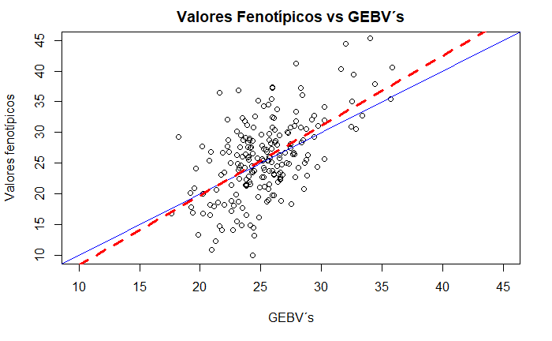

```r
abline(lm(g.vl~g.hat1), col="red", lwd=3, lty=2)
```

## Eficiência do modelo GBlup

```r
cor(g.hat1, g.vl)/0.67
```

```
          [,1]
[1,] 0.8460756
```

# Correalção entre os valores preditos

A correlação entre os valores preditos pelo modelo RRblup e GBlup foi de 0.99.

```r
cor(g.hat, g.hat1)
```

```
          [,1]
[1,] 0.9995376
```

# Correlação entre os efeitos dos marcadores

A correlação entre os valores estimados para os efeitos dos marcadores pelo modelo RRblup e GBlup foi de 0.99.

```r
cor(m.cat, m.cat1)
```

```
[1] 0.9972198
```

# Conclusões

A correlção entre os valores estimados para os efeitos dos marcadores para os dois modelos foi de 0.99. E a correlação entre os valores preditos para os dois modelos foi de 0.99.

Diante disso, pode-se dizer que os dois modelos chegaram a resultados bastante próximos.